# Tutorial 3: Manipulating Data in R

DPI R Bootcamp

Jared Knowles

# Overview

In this lesson we hope to learn:

- Aggregating data
- Organizing our data
- Manipulating vectors
- Dealing with missing data

# Again, read in our dataset

```r
# Set working directory to the tutorial directory In RStudio can do
# this in 'Tools' tab
setwd("~/GitHub/r_tutorial_ed")
# Load some data
load("data/smalldata.rda")
# Note if we don't assign data to 'df' R just prints contents of
# table
```

# Aggregation

- Sometimes we need to do some basic checking for the number of observations or types of observations in our dataset
- To do this quickly and easily - the `table` function is our friend
- Let's look at our observations by year and grade

```r
table(df$grade, df$year)
```

```
    2000 2001 2002
  3  200  100  200
  4  100  200  100
  5  200  100  200
  6  100  200  100
  7  200  100  200
  8  100  200  100
```

- The first command gives the rows, the second gives the columns
- Ugly, but effective

# Aggregation can be more complex

- Let's aggregate by race and year

```r
table(df$year, df$race)
```

```
         A   B   H   I   W
  2000  16 370  93   7 414
  2001  16 370  93   7 414
  2002  16 370  93   7 414
```

- Race is consistent across years, interesting
- What if we want to only look at 3rd graders that year?

# More complicated still

```r
with(df[df$grade == 3, ], {
    table(year, race)
})
```

```
      race
year     A   B   H   I   W
  2000   4  78  22   4  92
  2001   1  44   8   2  45
  2002   0  74  20   1 105
```

- `with` specifies a data object to work on, in this case all elements of `df` where `grade==3`
- `table` is the same command as above, but since we specified the data object in the `with` statement, we don't need the `df$` in front of the variables of interest

```r
df2 <- subset(df, grade == 3)
table(df2$year, df2$race)
```

```
         A   B   H   I   W
  2000   4  78  22   4  92
  2001   1  44   8   2  45
  2002   0  74  20   1 105
```

```r
rm(df2)
```

# Quick exercise

- Can you find the number of black students in each grade in each year?
- hint: **`with(df[df$___==___,]...)`**
- How many in year 2002, grade 6?
- 48
- How many in 2001, grade 7?
- 39

# Answer

```r
with(df[df$race=="B",],{table(year,grade)})
```

```
      grade
year    3  4  5  6  7  8
  2000 78 48 87 39 74 44
  2001 44 78 48 87 39 74
  2002 74 44 78 48 87 39
```

- Quick question, how can we understand the three types of closures we have in this function: **()** **[]** and **{}**

# Tables cont.

- This is really powerful for looking at the descriptive dimensions of the data, we can ask questions like:
- How many students are at each proficiency level each year?

```r
table(df$year, df$proflvl)
```

```
       advanced basic below basic proficient
  2000       56   313         143        388
  2001      229   183          64        424
  2002      503    27           3        367
```

- How many students are at each proficiency level by race?

```r
table(df$race, df$proflvl)
```

```
    advanced basic below basic proficient
  A       19     7           3         19
  B      160   302         162        486
  H       54    76          33        116
  I        7     4           1          9
  W      548   134          11        549
```

# Proportional Tables

- What if we aren't interested in counts?
- R makes it really easy to calculate proportions

```r
prop.table(table(df$race, df$proflvl))
```

```
     advanced     basic below basic proficient
  A 0.0070370 0.0025926   0.0011111  0.0070370
  B 0.0592593 0.1118519   0.0600000  0.1800000
  H 0.0200000 0.0281481   0.0122222  0.0429630
  I 0.0025926 0.0014815   0.0003704  0.0033333
  W 0.2029630 0.0496296   0.0040741  0.2033333
```

- Hmmm, this is goofy. This tells us the proportion of each cell out of the total. Also, the digits are distracting. How can we fix this?

# Try number 2

```r
round(prop.table(table(df$race, df$proflvl), 1), digits = 3)
```

```
    advanced basic below basic proficient
  A    0.396 0.146       0.062      0.396
  B    0.144 0.272       0.146      0.438
  H    0.194 0.272       0.118      0.416
  I    0.333 0.190       0.048      0.429
  W    0.441 0.108       0.009      0.442
```

- The `1` tells R we want proportions rowise, a `2` goes columnwise
- `round` tells R to cut off some digits for us
- Proportions are just that, not in percentage terms (we need to multiply by 100 for this)
- Can you make this table express percentages instead of proportions? How might that code look?
- A few more problems arise - this pools all observations, including students across years
- To avoid these, we need to aggregate the data somehow

# Checking Understanding

- We have seen how to chain functions together
- We have also seen how to examine a dataframe by looking at the observations in it
- We are now going to move on to aggregating data so we can look at unique cases when we have more than one observation for each unit

# Aggregating Data

- One of the most common questions you need to answer is to compute aggregates of data
- R has an `aggregate` function that can be used and helps us avoid the clustering problems above
- This works great for simple aggregation like scale score by race, we just need a `formula` (think I want variable X **by** grouping factor Y) and the statistic we want to compute

```r
# Reading Scores by Race
aggregate(readSS ~ race, FUN = mean, data = df)
```

```
  race readSS
1    A  508.7
2    B  460.2
3    H  473.2
4    I  485.2
5    W  533.2
```

# Aggregate (II)

- `aggregate` can take us a little further, we can use aggregate multiple variables at a time

```r
aggregate(cbind(readSS, mathSS) ~ race, data = df, mean)
```

```
  race readSS mathSS
1    A  508.7  477.9
2    B  460.2  442.5
3    H  473.2  442.7
4    I  485.2  455.9
5    W  533.2  529.8
```

- We can add multiple grouping varialbes using the `formula` syntax

```r
head(aggregate(cbind(readSS, mathSS) ~ race + grade, data = df, mean),
    8)
```

```
  race grade readSS mathSS
1    A     3  397.8  454.8
2    B     3  409.8  371.6
3    H     3  417.7  364.2
4    I     3  407.6  449.3
5    W     3  481.1  450.7
6    A     4  456.0  438.2
7    B     4  426.9  408.1
8    H     4  418.8  404.6
```

# Crosstabs

- We can build a systematic cross-tab now

```r
ag <- aggregate(readSS ~ race + grade, data = df, mean)
xtabs(readSS ~ ., data = ag)
```

```
    grade
race     3     4     5     6     7     8
   A 397.8 456.0 479.1 539.5 600.4 605.3
   B 409.8 426.9 447.6 470.9 492.3 523.5
   H 417.7 418.8 481.2 489.1 500.3 534.2
   I 407.6 531.1 547.6   0.0 405.5 518.0
   W 481.1 498.5 517.1 546.6 565.2 596.1
```

- And prettier output

```r
ftable(xtabs(readSS ~ ., data = ag))
```

```
     grade     3     4     5     6     7     8
race
A          397.8 456.0 479.1 539.5 600.4 605.3
B          409.8 426.9 447.6 470.9 492.3 523.5
H          417.7 418.8 481.2 489.1 500.3 534.2
I          407.6 531.1 547.6   0.0 405.5 518.0
W          481.1 498.5 517.1 546.6 565.2 596.1
```

# Check your work

- What is the mean reading score for 6th grade students with disabilities?
- **481.83**
- How many points is this from non-disabled students?
- **29.877**

# Answer II

```r
aggregate(cbind(readSS, mathSS) ~ disab + grade, data = df, mean)
```

```
   disab grade readSS mathSS
1      0     3  449.9  418.3
2      1     3  421.1  376.3
3      0     4  464.0  454.2
4      1     4  438.2  425.1
5      0     5  484.9  470.2
6      1     5  475.1  431.0
7      0     6  511.7  507.9
8      1     6  481.8  476.9
9      0     7  532.0  532.0
10     1     7  516.1  474.3
11     0     8  567.6  567.7
12     1     8  518.8  534.1
```

# School Means

- Consider the case we want to turn our student level data into school level data
- Who hasn't had to do this?!?
- In `aggregate` we do:

```r
z <- aggregate(readSS ~ dist, FUN = mean, data = df)
z
```

```
  dist readSS
1  205  496.5
2  402  500.5
3  495  491.6
```

- But I want more! I want to aggregate multiple variables. I want to do it across multiple groups. I want the output to be a dataframe I can work on.
- Thank you `plyr`

# Aggregate Isn't Enough

- `aggregate` is cool, but it isn't very flexible
- We can only use aggregate output as a table, which we have to convert to a data frame
- There is a better way; the `plyr` package
- `plyr` is a set of routines/logical structure for transforming, summarizing, reshaping, and reorganizing data objects of one type in R into another type (or the same type)
- We will focus here on summarizing and aggregating a data frame, but later in the bootcamp we'll apply functions to lists and turn lists into data frames as well
- This is cool!

# The Logic of plyr

- In R this is known as "split, apply, and combine"
- Why? First, we **split** the data into groups by some factor or logical operator
- Then we **apply** some function or another to that group (i.e. count the unique values of a variable, take the mean of a variable, etc.)
- Then we **combine** the data back together
- This has some advantages - unlike other methods, the data does not have to be ordered by our ID variable for this to work
- The disadvantage is that this method is computationally expensive, even in R, and requires copying our data frame using up RAM

# An Aside about Split-Apply-Combine

- The `plyr` package has a number of utilities to help us split-apply-combine across data types for both input and output
- In R we can't just use `for` loops to iterate over groups of students, because in R `for` loops are [slow, inefficient, and impractical](http://stackoverflow.com/questions/7142767/why-are-loops-slow-in-r)
- `plyr` to the rescue, while not as fast as a compiled language, it is pretty dang good!
- And still readable

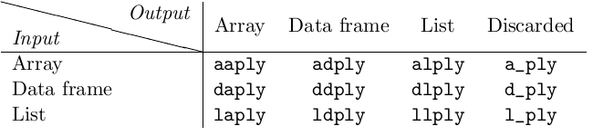

# The logic of plyr

- This shows how the dataframe is broken up into pieces and each piece then gets whatever functions, summaries, or transformations we apply to it

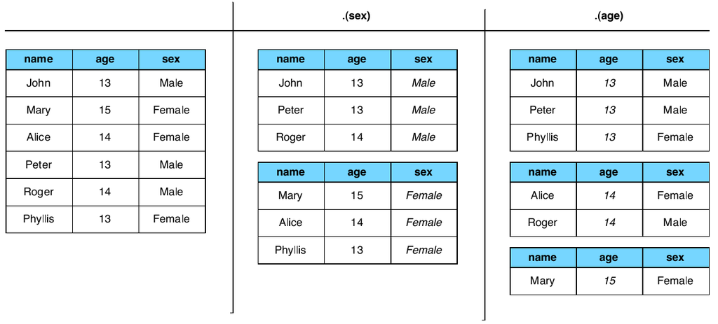

# How plyr works on dataframes

- And this shows the output `ddply` has before it combines it back for us when we do the call `ddply(df,.(sex,age),"nrow")`

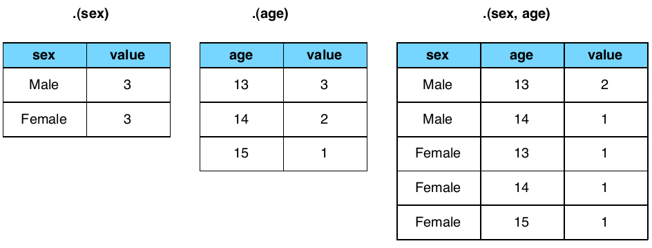

# Using plyr

- `plyr` has a straightforward syntax
- All `plyr` functions are in the format **XX**ply. The two X's specify what the input file we are applying a function to is, and then what way we would like it outputted.
- In `plyr` d = dataframe, l= list, m=matrix, and a=array. By far the most common usage is `ddply`
- From a dataframe, to a dataframe.
- We will see more of `plyr` in Tutorial 4 as well

# plyr in Action

```r
  library(plyr)
myag<-ddply(df, .(dist,grade),summarize,
            mean_read=mean(readSS,na.rm=T),
            mean_math=mean(mathSS,na.rm=T),
            sd_read=sd(readSS,na.rm=T),
            sd_math=sd(mathSS,na.rm=T),
            count_read=length(readSS),
            count_math=length(mathSS))
```

- This looks complex, but it only has a few components.
- The first argument is the dataframe we are working on, the next argument is the level of identification we want to aggregate to
- `summarize` tells `ddply` what we are doing to the data frame
- Then we make a list of new variable names, and how to calculate them on each of the subsets in our large data frame
- That's it!